# StatFest_TM

Mengqian LU

Nov 14, 2015

This is an illustration of typical procedures to learn from collections of **text** documents. This module is designated for the **StatFest 2015 “Data+Journalism” Hackathon** hosted by Columbia Statsistics Club in Columbia University.

The document is available on https://github.com/MRandomMax/StatFest_2015

# I. Load and Explore a Corpus

### I.1. Install packages:

```r
## wordcloud -- plot a word cloud
## biclust -- Data preprocessing (normalization and discretisation),
##            visualisation, and validation of bicluster
## tm -- Framework for text mining.
## SnowballC -- Provides wordStem() for stemming.
## dplyr -- Data preparation and pipes.
## RColorBrewer -- Generate palette of colours for plots.
## ggplot2 -- Plot word frequencies.
## scales -- Include commas in numbers.
## Rgraphviz -- Correlation plots.
## fpc - Flexible Procedures for Clustering

require('wordcloud')
require('biclust')
require('cluster')
require('igraph')
require('dplyr')
require('scales')
require('SnowballC')
require('RColorBrewer')
require('ggplot2')
require('tm')
require('Rgraphviz')
require('fpc')
```

### I.2. Load the Corpus

```r
getSources()
```

```
## [1] "DataframeSource" "DirSource"       "URISource"       "VectorSource"
## [5] "XMLSource"       "ZipSource"
```

```r
getReaders()
```

```
##  [1] "readDOC"                 "readPDF"
##  [3] "readPlain"               "readRCV1"
##  [5] "readRCV1asPlain"         "readReut21578XML"
##  [7] "readReut21578XMLasPlain" "readTabular"
##  [9] "readTagged"              "readXML"
```

```r
# Windows
mypwd = file.path('C:','MENGQIAN LU','Columbia Stat Club',
                  'StatFest_2015','Data')
mypwd
```

```
## [1] "C:/MENGQIAN LU/Columbia Stat Club/StatFest_2015/Data"
```

```r
## Mac
mypwd = file.path('~','Desktop','Columbia Stat Club','StatFest_2015','Data')
mypwd
```

```
## [1] "~/Desktop/Columbia Stat Club/StatFest_2015/Data"
```

```r
## Check what is under your present working directory
dir(mypwd)
```

```
## [1] "doc1.txt"                     "doc2.txt"
## [3] "doc3.txt"                     "stateoftheunion1790-2012.txt"
```

```r
## To load a Corpus of text documents
docs = Corpus(DirSource(mypwd))
```

### I.3. Explore the Corpus

```r
class(docs)
class(docs[[1]])
inspect(docs[1])
```

```
## [1] "VCorpus" "Corpus"
## [1] "PlainTextDocument" "TextDocument"
## <<VCorpus>>
## Metadata:  corpus specific: 0, document level (indexed): 0
## Content:  documents: 1
##
## [[1]]
## <<PlainTextDocument>>
## Metadata:  7
## Content:  chars: 1152
```

# II. Pre-processing your text documents, the ‘Corpus’

#### *tm_map* – Ensure all transformation are applied to all documents within the Corpus

### II.1. Simple replacement

We will be using the *‘crude’* data for the following demonstration.

```r
data('crude')
docs = crude
docs
```

```
## <<VCorpus>>
## Metadata:  corpus specific: 0, document level (indexed): 0
## Content:  documents: 20
```

```r
toSpace = content_transformer(function(yourdata, target) gsub(target, ' ', yourdata))
docs = tm_map(docs, toSpace, "/")
docs = tm_map(docs, toSpace, "@")
inspect(docs[1])
```

```
## <<VCorpus>>
## Metadata:  corpus specific: 0, document level (indexed): 0
## Content:  documents: 1
##
## $`reut-00001.xml`
## <<PlainTextDocument>>
## Metadata:  15
## Content:  chars: 527
```

#### Note: search **regular expression in R** for more information on how to define a search pattern for your *target* value

### II.2. To Lowercase

```r
docs <- tm_map(docs, content_transformer(tolower))
```

### II.3. Remove numbers

```r
docs = tm_map(docs, removeNumbers)
```

### II.4. Remove punctuation

```r
docs = tm_map(docs, removePunctuation)
```

### II.5. Remove stopwords

words like **‘for’,‘very’,‘of’** are common stop words.

```r
length(stopwords('english'))
```

```
## [1] 174
```

```r
stopwords('english')
```

```
##   [1] "i"          "me"         "my"         "myself"     "we"
##   [6] "our"        "ours"       "ourselves"  "you"        "your"
##  [11] "yours"      "yourself"   "yourselves" "he"         "him"
##  [16] "his"        "himself"    "she"        "her"        "hers"
##  [21] "herself"    "it"         "its"        "itself"     "they"
##  [26] "them"       "their"      "theirs"     "themselves" "what"
##  [31] "which"      "who"        "whom"       "this"       "that"
##  [36] "these"      "those"      "am"         "is"         "are"
##  [41] "was"        "were"       "be"         "been"       "being"
##  [46] "have"       "has"        "had"        "having"     "do"
##  [51] "does"       "did"        "doing"      "would"      "should"
##  [56] "could"      "ought"      "i'm"        "you're"     "he's"
##  [61] "she's"      "it's"       "we're"      "they're"    "i've"
##  [66] "you've"     "we've"      "they've"    "i'd"        "you'd"
##  [71] "he'd"       "she'd"      "we'd"       "they'd"     "i'll"
```

[output cut: 20 more lines]

```r
docs = tm_map(docs, removeWords, stopwords("english"))
```

### II.6. Remove own stop words

This step is **optional** for pre-processing.

```r
docs = tm_map(docs, removeWords,c('school','department'))
```

### II.7. Define your acronym

```r
toString = content_transformer(function(x,from,to) gsub(from,to,x))
docs = tm_map(docs, toString, 'Columbia Statistics Club','CSC')
docs = tm_map(docs, toString,'Earth and Environmental Engineering', 'EAEE')
```

### II.8. “Stemming” your documents

A word can then be recognizable to the computer, despite whether or not it may have a variety of possible endings, such as “ing”, “es” or “s”

```r
docs = tm_map(docs,stemDocument)
```

### II.9. Stripping the whitespace due to previous “Stemming” process

```r
docs = tm_map(docs,stripWhitespace)
```

### II.10. Tell R your docs are ready as “Plain Text Documents”

Once you have completed your pre-processing of the text documents, or your Corpus. Get the text ready as **plain text documents**. This step is crucial, and it is the end of the pre-processing stage.

```r
docs = tm_map(docs,PlainTextDocument)
```

# III. Explore the data

First create a document-term matrix and a term-document matrix, which describes the frequency of terms that occur in a collection of documents. These are what you will be using from this point on. In a document-term matrix, rows correspond to documents in the collection and columns correspond to terms.

```r
dtm = DocumentTermMatrix(docs)
dtm
dim(dtm) # display the dimensions
```

```
## <<DocumentTermMatrix (documents: 20, terms: 866)>>
## Non-/sparse entries: 1627/15693
## Sparsity           : 91%
## Maximal term length: 16
## Weighting          : term frequency (tf)
## [1]  20 866
```

```r
inspect(dtm[1:5,1:20])
#Avoiding fill up your memory, inspect a subset of the document-term matrix. This subset views first 5 docs & first 20 terms
```

```
## <<DocumentTermMatrix (documents: 5, terms: 20)>>
## Non-/sparse entries: 6/94
## Sparsity           : 94%
## Maximal term length: 10
## Weighting          : term frequency (tf)
##
##       Terms
## Docs   abdulaziz abil abl abroad accept accord across act activity add
##   doc1         0    0   0      0      0      0      0   0        0   0
##   doc2         0    2   0      0      0      0      0   0        0   0
##   doc3         0    0   0      0      0      0      0   0        0   0
##   doc4         0    0   0      0      0      0      0   0        0   0
##   doc5         0    0   0      0      0      0      0   0        0   0
##       Terms
## Docs   added address adher advantag advisers agenc agr agre agreement
##   doc1     0       0     0        0        0     0   0    0         0
##   doc2     1       4     0        1        0     0   1    0         1
##   doc3     0       0     0        0        0     0   0    0         0
##   doc4     0       0     0        0        0     0   0    0         0
##   doc5     0       0     0        0        0     0   0    0         0
##       Terms
## Docs   agricultur
##   doc1          0
##   doc2          0
##   doc3          0
##   doc4          0
##   doc5          0
```

A term-document matrix is the transpose of the document-term matrix.

```r
tdm = TermDocumentMatrix(docs)
tdm
dim(tdm)
```

```
## <<TermDocumentMatrix (terms: 866, documents: 20)>>
## Non-/sparse entries: 1627/15693
## Sparsity           : 91%
## Maximal term length: 16
## Weighting          : term frequency (tf)
## [1] 866  20
```

```r
inspect(tdm[1:20,1:5]) #compare to your dtm
```

```
## <<TermDocumentMatrix (terms: 20, documents: 5)>>
## Non-/sparse entries: 6/94
## Sparsity           : 94%
## Maximal term length: 10
## Weighting          : term frequency (tf)
##
##             Docs
## Terms        doc1 doc2 doc3 doc4 doc5
##   abdulaziz     0    0    0    0    0
##   abil          0    2    0    0    0
##   abl           0    0    0    0    0
##   abroad        0    0    0    0    0
##   accept        0    0    0    0    0
##   accord        0    0    0    0    0
##   across        0    0    0    0    0
##   act           0    0    0    0    0
##   activity      0    0    0    0    0
##   add           0    0    0    0    0
##   added         0    1    0    0    0
##   address       0    4    0    0    0
##   adher         0    0    0    0    0
##   advantag      0    1    0    0    0
##   advisers      0    0    0    0    0
##   agenc         0    0    0    0    0
##   agr           0    1    0    0    0
##   agre          0    0    0    0    0
##   agreement     0    1    0    0    0
##   agricultur    0    0    0    0    0
```

```r
# save dtm or tdm as .csv for future use if you like
write.csv(as.matrix(dtm),file='dtm.csv')
write.csv(as.matrix(tdm),file='tdm.csv')
```

## III.1. Individual level: Frequencies and counts

III.1.(a) Organize terms by their frequencies and explore by plots

```r
mfreq = colSums(as.matrix(dtm))
length(mfreq)
```

```
## [1] 866
```

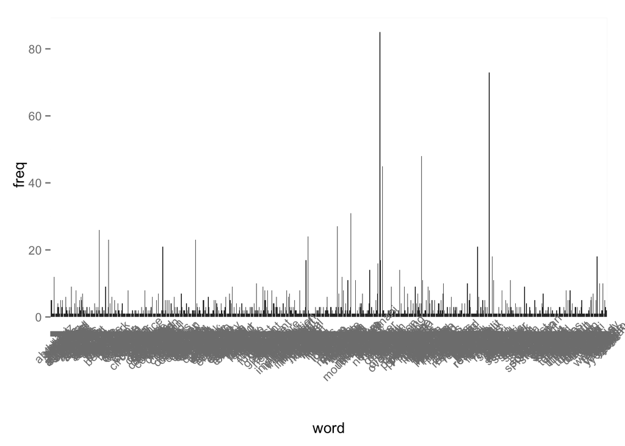

```r
p1 = ggplot(data.frame(word=names(mfreq),freq=mfreq),aes(word,freq))+ geom_bar(stat='identity') + theme(axis.text.x=element_text(angle=45,hjust=0.5))
p1
```

## Too busy? let’s just view some of them with a threshold

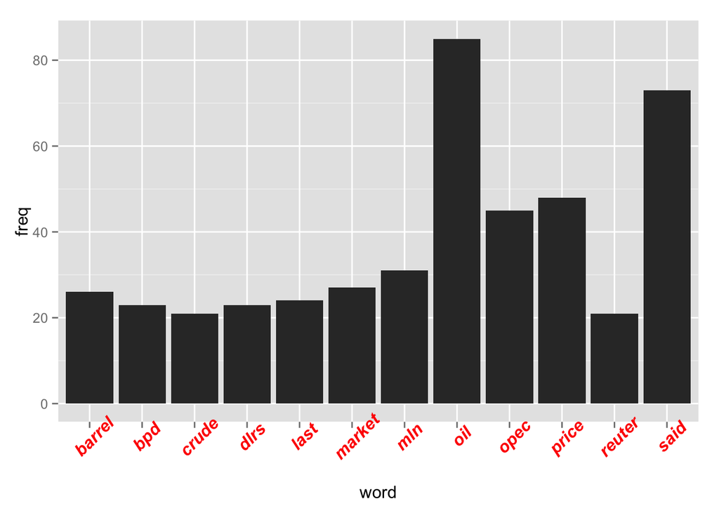

```r
p1 = ggplot(subset(data.frame(word=names(mfreq),freq=mfreq),freq>20),aes(word,freq))+ geom_bar(stat='identity') + theme(axis.text.x=element_text(size=12,color='red',fac='bold.italic',angle=45,hjust=0.5))
p1
```

III.1.(b) Check most and least frequently occuring words

```r
mord = order(mfreq, decreasing=TRUE) #increasing order as default
mfreq[head(mord,20)]
```

```
##    oil   said  price   opec    mln market barrel   last    bpd   dlrs
##     85     73     48     45     31     27     26     24     23     23
##  crude reuter  saudi   will kuwait    one offici    new    pct accord
##     21     21     18     18     17     17     16     14     14     12
```

```r
mfreq[tail(mord,10)]
```

```
##     weeks    welcom   whether      wint    winter      wish worldwide
##         1         1         1         1         1         1         1
##       xon     years    yergin
##         1         1         1
```

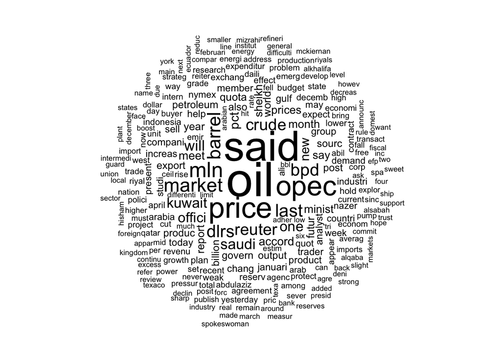

```r
# Visualize it if you like
set.seed(100) # if you'd like to make the configuration of the layout consistent each time
wordcloud(names(mfreq),mfreq,
          random.color=FALSE,
          # colors chosen randomly or based on the frequency
          random.order=FALSE) # plot in an dreasing frequency
```

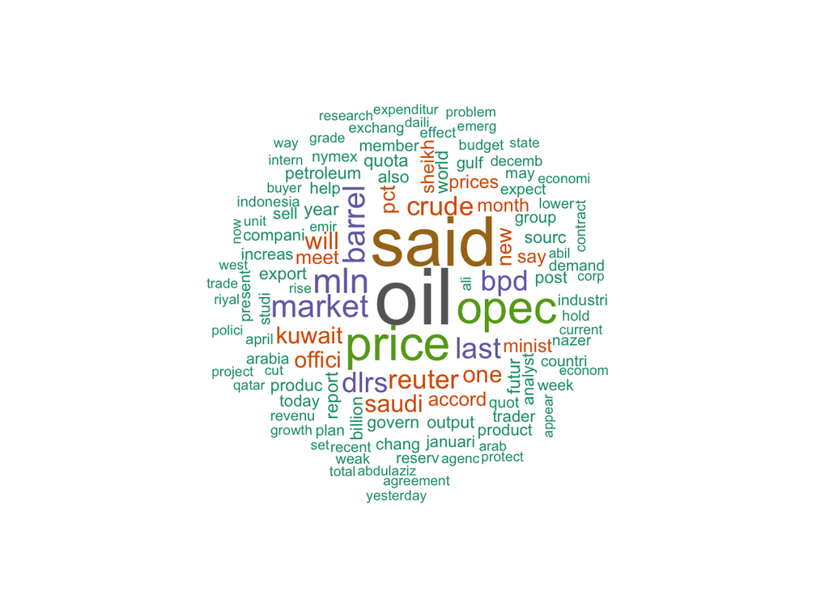

```r
set.seed(100)
wordcloud(names(mfreq),mfreq,
          min.freq=5, # plot words apprear 10+ times
          scale=c(4,0.5), # make it bigger with argument "scale"
          colors=brewer.pal(8, "Dark2"), # use color palettes
          random.color=FALSE,
          random.order=FALSE)
```

III.1.(3) Check the frequency of frequencies, insight on the overall distribution of the frequencies of the bags of words

```r
head(table(mfreq),20)
```

```
## mfreq
##   1   2   3   4   5   6   7   8   9  10  11  12  14  16  17  18  21  23
## 483 136  93  38  36  13  14  13   9   5   5   2   2   1   2   2   2   2
##  24  26
##   1   1
```

```r
#The top number is the frequency with which words appear and the bottom number reflects how many words appear that frequently.
tail(table(mfreq), 20)
```

```
## mfreq
##  7  8  9 10 11 12 14 16 17 18 21 23 24 26 27 31 45 48 73 85
## 14 13  9  5  5  2  2  1  2  2  2  2  1  1  1  1  1  1  1  1
```

#### Further removing sparse terms

```r
dtm
```

```
## <<DocumentTermMatrix (documents: 20, terms: 866)>>
## Non-/sparse entries: 1627/15693
## Sparsity           : 91%
## Maximal term length: 16
## Weighting          : term frequency (tf)
```

```r
inspect(removeSparseTerms(dtm, 0.6)) #better inspect first
```

```
## <<DocumentTermMatrix (documents: 20, terms: 17)>>
## Non-/sparse entries: 206/134
## Sparsity           : 39%
## Maximal term length: 9
## Weighting          : term frequency (tf)
##
##        Terms
## Docs    also barrel crude dlrs last market mln new oil one opec pct
##   doc1     0      2     2    2    1      1   0   0   5   0    0   0
##   doc2     0      0     0    0    1      4   4   1  12   1   15   0
##   doc3     0      1     2    1    1      0   0   0   2   0    0   0
##   doc4     0      1     3    2    1      0   0   0   1   1    0   0
##   doc5     0      0     0    2    0      0   2   0   1   0    0   2
##   doc6     1      4     2    2    4      3   4   1   7   1    7   0
##   doc7     1      0     0    1    3      0   1   3   3   1    1   2
##   doc8     1      0     0    0    0      2   0   1   3   1    2   2
##   doc9     1      1     0    0    2      0   0   0   5   0    1   2
##   doc10    1      3     0    4    1      9   3   0   9   1    6   1
##   doc11    0      3     5    2    7      1   9   1   5   1    5   0
##   doc12    0      0     2    0    1      2   0   0   4   0    2   0
##   doc13    0      1     0    0    1      2   0   0   5   0    2   1
##   doc14    1      1     2    0    1      0   0   0   4   1    4   0
##   doc15    0      0     0    0    0      0   0   2   3   0    0   0
##   doc16    1      3     0    1    0      0   3   1   4   2    0   1
##   doc17    1      3     0    1    0      0   3   1   5   2    0   1
##   doc18    1      1     2    5    0      0   0   0   3   1    0   0
##   doc19    0      0     0    0    0      3   0   3   3   4    0   0
##   doc20    0      2     1    0    0      0   2   0   1   0    0   2
##        Terms
## Docs    petroleum price reuter said will
##   doc1          0     5      1    3    0
##   doc2          1     5      2   11    3
##   doc3          0     2      1    1    1
##   doc4          1     2      1    1    1
##   doc5          1     0      1    3    0
##   doc6          0     5      1   10    2
##   doc7          1     1      1    1    0
##   doc8          0     0      1    3    1
##   doc9          1     1      1    5    0
##   doc10         0     6      1    7    1
##   doc11         1     4      1    8    1
##   doc12         1     0      1    1    1
##   doc13         0     5      1    2    1
##   doc14         0     1      1    1    0
##   doc15         0     0      1    3    0
##   doc16         1     3      1    2    0
##   doc17         1     3      1    2    0
##   doc18         0     3      1    4    0
##   doc19         0     2      1    4    6
##   doc20         0     0      1    1    0
```

```r
# Normally this reduces the matrix dramatically without losing significant relations inherent to the matrix:
dtmc = removeSparseTerms(dtm,sparse=0.6)
tdmc = removeSparseTerms(tdm,sparse=0.6)
# argument "sparse" is a numeric for the maximal allowed sparsity in the range [0 1].
```

### Now the new wordcloud looks like this:

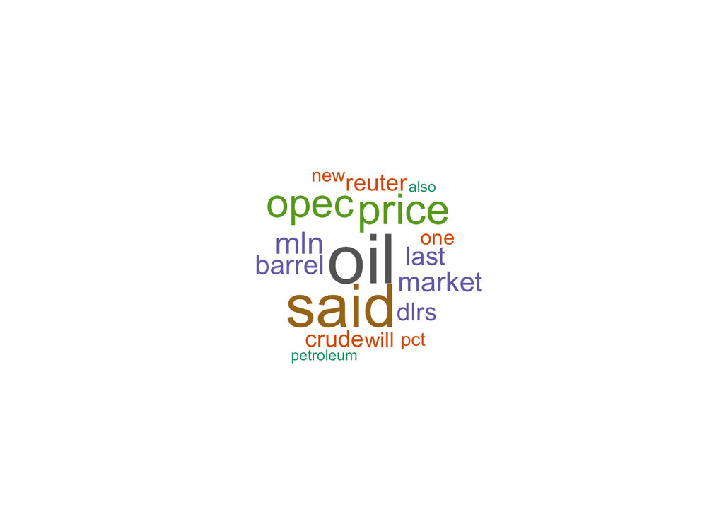

```r
mfreq = colSums(as.matrix(dtmc))
set.seed(100)
wordcloud(names(mfreq),mfreq,
          min.freq=5, # plot words apprear 10+ times
          scale=c(4,0.5), # make it bigger with argument "scale"
          colors=brewer.pal(8, "Dark2"), # use color palettes
          random.color=FALSE,
          # colors chosen randomly or based on the frequency
          random.order=FALSE) # plot in an dreasing frequency
```

```r
dim(dtmc)
```

```
## [1] 20 17
```

```r
inspect(dtmc)
```

```
## <<DocumentTermMatrix (documents: 20, terms: 17)>>
## Non-/sparse entries: 206/134
## Sparsity           : 39%
## Maximal term length: 9
## Weighting          : term frequency (tf)
##
##        Terms
## Docs    also barrel crude dlrs last market mln new oil one opec pct
##   doc1     0      2     2    2    1      1   0   0   5   0    0   0
##   doc2     0      0     0    0    1      4   4   1  12   1   15   0
##   doc3     0      1     2    1    1      0   0   0   2   0    0   0
##   doc4     0      1     3    2    1      0   0   0   1   1    0   0
##   doc5     0      0     0    2    0      0   2   0   1   0    0   2
##   doc6     1      4     2    2    4      3   4   1   7   1    7   0
##   doc7     1      0     0    1    3      0   1   3   3   1    1   2
##   doc8     1      0     0    0    0      2   0   1   3   1    2   2
##   doc9     1      1     0    0    2      0   0   0   5   0    1   2
##   doc10    1      3     0    4    1      9   3   0   9   1    6   1
##   doc11    0      3     5    2    7      1   9   1   5   1    5   0
##   doc12    0      0     2    0    1      2   0   0   4   0    2   0
##   doc13    0      1     0    0    1      2   0   0   5   0    2   1
##   doc14    1      1     2    0    1      0   0   0   4   1    4   0
##   doc15    0      0     0    0    0      0   0   2   3   0    0   0
##   doc16    1      3     0    1    0      0   3   1   4   2    0   1
##   doc17    1      3     0    1    0      0   3   1   5   2    0   1
##   doc18    1      1     2    5    0      0   0   0   3   1    0   0
##   doc19    0      0     0    0    0      3   0   3   3   4    0   0
##   doc20    0      2     1    0    0      0   2   0   1   0    0   2
##        Terms
## Docs    petroleum price reuter said will
##   doc1          0     5      1    3    0
##   doc2          1     5      2   11    3
##   doc3          0     2      1    1    1
##   doc4          1     2      1    1    1
##   doc5          1     0      1    3    0
##   doc6          0     5      1   10    2
##   doc7          1     1      1    1    0
##   doc8          0     0      1    3    1
##   doc9          1     1      1    5    0
##   doc10         0     6      1    7    1
##   doc11         1     4      1    8    1
##   doc12         1     0      1    1    1
##   doc13         0     5      1    2    1
##   doc14         0     1      1    1    0
##   doc15         0     0      1    3    0
##   doc16         1     3      1    2    0
##   doc17         1     3      1    2    0
##   doc18         0     3      1    4    0
##   doc19         0     2      1    4    6
##   doc20         0     0      1    1    0
```

III.1.(4) Find terms with frequency bounds

```r
mfreq = colSums(as.matrix(dtm))
findFreqTerms(dtm, lowfreq = 30, highfreq = 90)
```

```
## [1] "mln"   "oil"   "opec"  "price" "said"
```

```r
# or tabulate it first and find by your eyes
bagwords = data.frame(word=names(mfreq),freq=as.vector(mfreq))
head(bagwords,20)
```

```
##          word freq
## 1   abdulaziz    5
## 2        abil    5
## 3         abl    1
## 4      abroad    1
## 5      accept    1
## 6      accord   12
## 7      across    1
## 8         act    1
## 9    activity    1
## 10        add    1
## 11      added    3
## 12    address    4
## 13      adher    3
## 14   advantag    1
## 15   advisers    1
## 16      agenc    5
## 17        agr    1
## 18       agre    3
## 19  agreement    5
## 20 agricultur    1
```

```r
head(sort(bagwords[,2],decreasing = TRUE),10)
```

```
##  [1] 85 73 48 45 31 27 26 24 23 23
```

## III.2.Between words: association and clustering

### III.2.(1) Words association – equals to 1 when words always appear together; equals to 0 when they never do

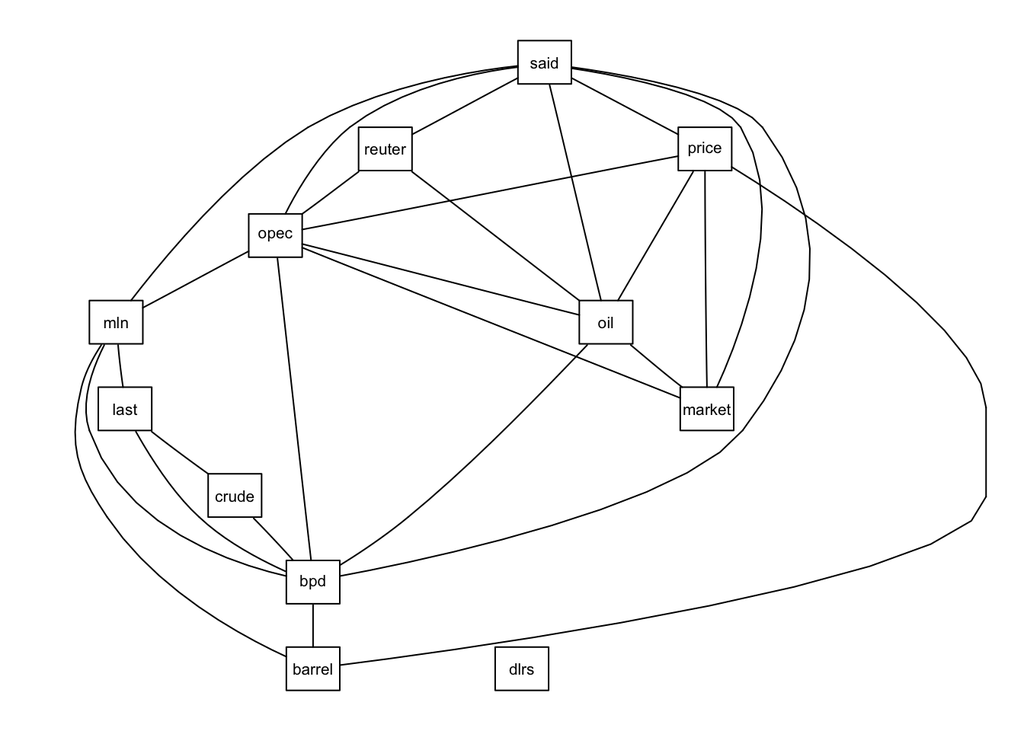

```r
# package: Rgraphviz
plot(dtm,terms=findFreqTerms(dtm,lowfreq = 20),corThreshold = 0.5)
```

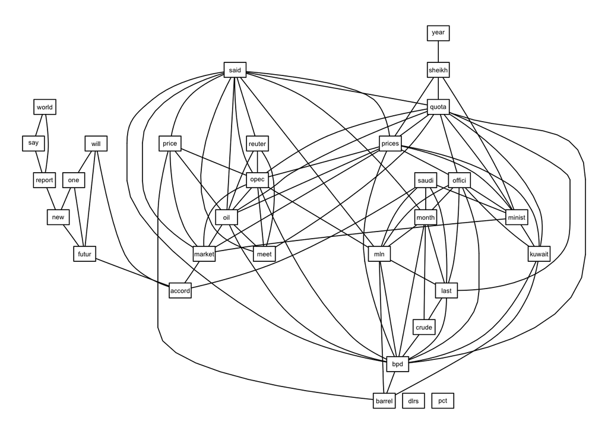

```r
plot(dtm,terms=findFreqTerms(dtm,lowfreq = 10),corThreshold = 0.5)
```

```r
cor1 = findAssocs(dtm,terms=c('oil','waste'),corlimit=c(0.7,0.8))
cor1
```

```
## $oil
##       opec      emerg       name        tri       want    analyst
##       0.86       0.81       0.81       0.81       0.81       0.79
##      clear     condit       late       said       meet production
##       0.79       0.79       0.79       0.78       0.77       0.73
##      price    markets
##       0.72       0.71
##
## $waste
## numeric(0)
```

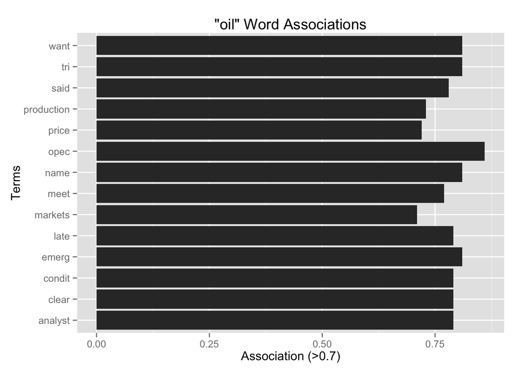

```r
qplot(names(cor1$oil),cor1$oil,stat='identity',decreasing=T,main="\"oil\" Word Associations",geom='bar',xlab='Terms',ylab='Association (>0.7)') + coord_flip()
```

### III.2.(2) Clustering by term similarity

### Types of Clustering

#### Hierachical clustering (e.g., agglomerative, divisive clustering)

- Partitions can be visualized using a tree structure (dendrogram)
- Does not need the number of clusters as input
- Possible to view partitions at different levels of granularities using different K

#### Flat or Partitional clustering (e.g., K-means, Gaussian mixture models and etc.)

- Partitions are independent of each other

#### III.2.(2).a **Hierarchal Clustering**

```r
mdist = dist(tdmc,method='euclidian')
mfit = hclust(d=mdist,method='ward.D2')
mfit
```

```
##
## Call:
## hclust(d = mdist, method = "ward.D2")
##
## Cluster method   : ward.D2
## Distance         : euclidean
## Number of objects: 17
```

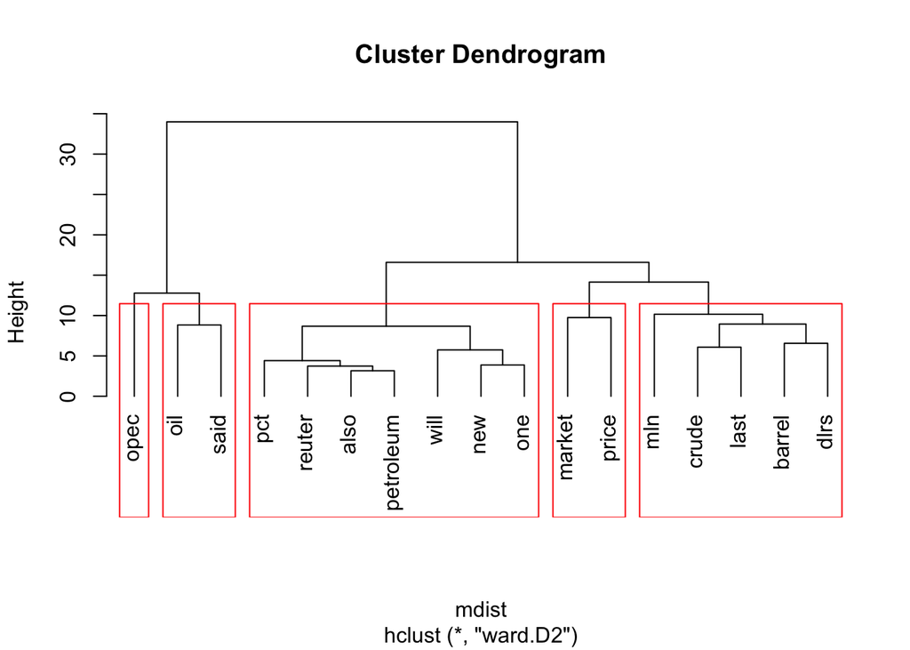

```r
plot(mfit,hang=-1)
# draw dendrogram with red borders that identify groups
rect.hclust(mfit,k=5,border='red')
```

```r
# you can also cut the tree into groups of data
grps = cutree(mfit,k=c(3,5,7)) # specify No. of clusters you want
# compare different groupings
table(grp2=grps[,'3'],grp4=grps[,'5'])
```

```
##     grp4
## grp2 1 2 3 4 5
##    1 7 0 0 0 0
##    2 0 5 2 0 0
##    3 0 0 0 2 1
```

#### III.2.(2).b **K-means Clustering**

cluster words into groups to minimize the total sum of the squared distance of every point to its corresponding cluster centroid. Particitions are independent of each other.

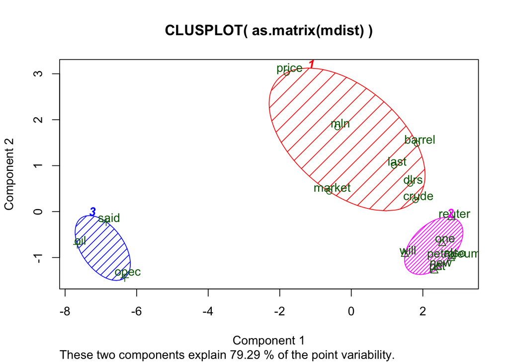

```r
mkm = kmeans(mdist,3)
clusplot(as.matrix(mdist),mkm$cluster,color=T,shade=T,labels=2,lines=0)
```

### NOTES:

### Hierarchical Clustering vs. K-means

- K-means clustering produces a single partitioning
- Hierarchical clustering can give diﬀerent partitionings depending on the level-of-resolution we are looking at
- K-means clustering needs the number of clusters to be speciﬁed
- Hierarchical clustering doesn’t need the number of clusters to be speciﬁed
- K-means clustering is usually more eﬃcient run-time wise
- Hierarchical clustering can be slow (has to make several merge/split decisions)
- No clear consensus on which of the two produces better clustering

## IV. Topic Modeling

```r
require(topicmodels)
dtm2 = as.DocumentTermMatrix(tdmc)
mlda = LDA(dtm2,k=3) #find k topics
mterms = terms(mlda,4) # find the first 4 terms of each topic
mterms
```

```
##      Topic 1 Topic 2 Topic 3
## [1,] "said"  "oil"   "oil"
## [2,] "price" "said"  "said"
## [3,] "oil"   "price" "opec"
## [4,] "opec"  "dlrs"  "mln"
```

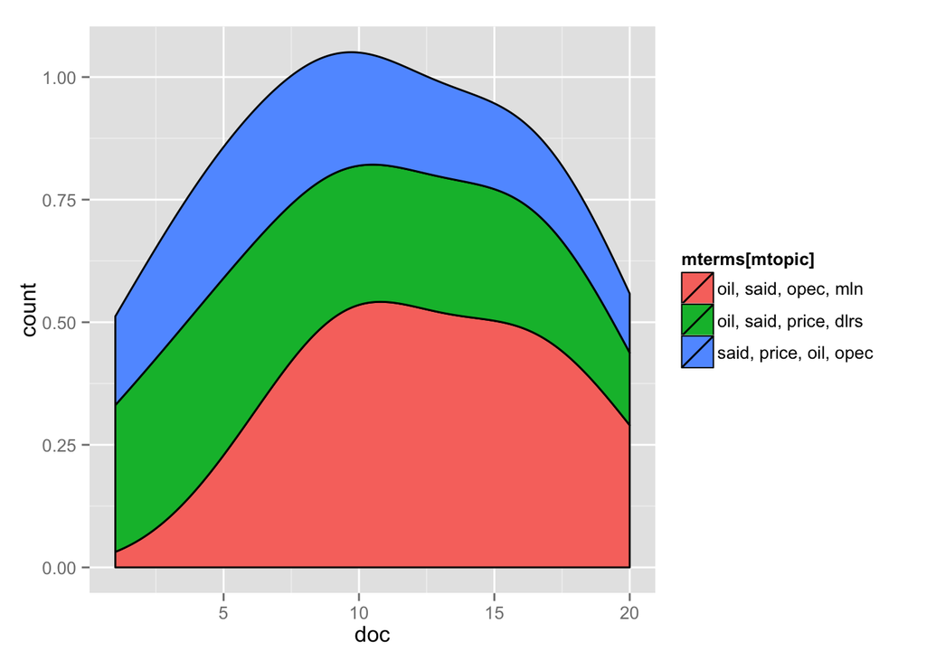

```r
mterms = apply(mterms,MARGIN=2,paste,collapse=', ')
# First topic identified for every document
mtopic = topics(mlda,1)
mtopics = data.frame(doc=1:20,topic1=mtopic)
qplot(doc,..count..,data=mtopics,geom='density',
      fill=mterms[mtopic],position='stack')
```